# Special topics in `ggplot2`

Jane Sullivan (jane.sullivan1@alaska.gov)

2018-09-06

# Topics for today

- Themes in `ggplot2`
- Customizing tick marks on a figure axis with `tickr()`
- Multipaneled plots in `cowplot`
- Better labels with `ggrepel`
- Resources for colour graphics

# Themes

## Base figure using default `ggplot2` theme

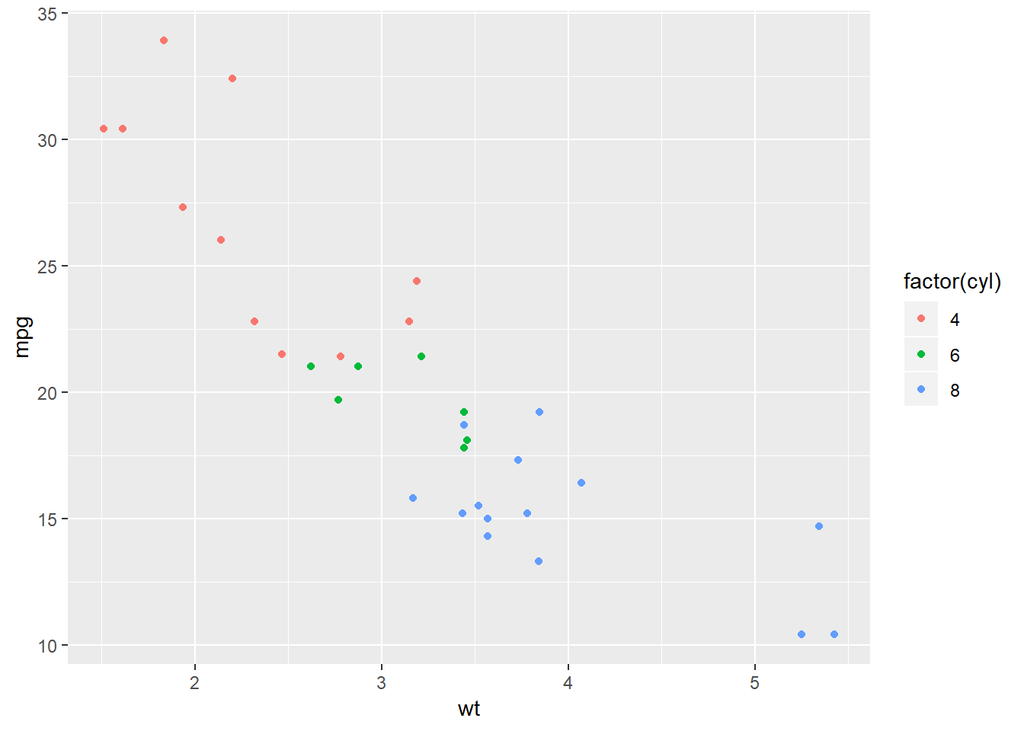

```r
p <- ggplot(mtcars, aes(x = wt, y = mpg, colour = factor(cyl))) +
  geom_point()

p
```

## Same figure with builtin `cowplot` theme

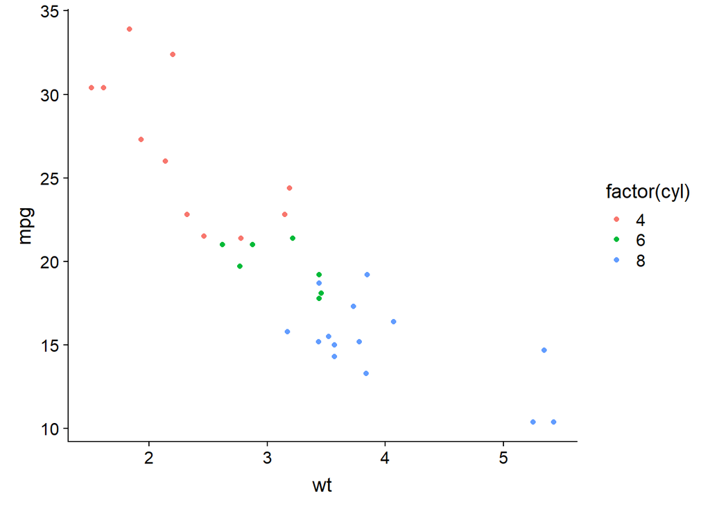

```r
if(!require("cowplot"))   install.packages("cowplot") # plot_grid and so much else

p
```

Cowplot has other built-in themes that you can explore, including those with minimal gridlines and ones built for mapping. You can explore the code under the themes at https://github.com/wilkelab/cowplot/blob/master/R/themes.R.

## Custom theme

Alternatively, you can create a custom theme, which is particularly useful if you’re following the style guides for a journal submission or creating a special set of figures for a poster or presentation. For example, if you want simple theme with a muted panel border and Times New Roman font (HINT: This is Ben’s theme), you can use the following code:

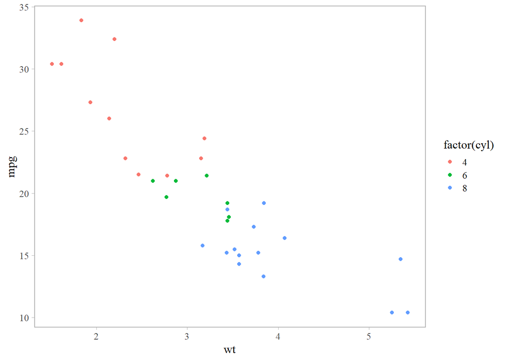

```r
windowsFonts(Times=windowsFont("Times New Roman"))

theme_sleek <- function(base_size = 12, base_family = "Times") {
  half_line <- base_size/2
  theme_light(base_size = 12, base_family = "Times") +
    theme(
      panel.grid.major = element_blank(),
      panel.grid.minor = element_blank(),
      axis.ticks.length = unit(half_line / 2.2, "pt"),
      strip.background = element_rect(fill = NA, colour = NA),
      strip.text.x = element_text(colour = "black"),
      strip.text.y = element_text(colour = "black"),
      panel.border = element_rect(fill = NA),
      legend.key.size = unit(0.9, "lines"),
      legend.key = element_rect(colour = NA, fill = NA),
      legend.background = element_rect(colour = NA, fill = NA)
    )
}

theme_set(theme_sleek())

p
```

Once we call a theme using the function `theme_set()`, it will apply this theme to all subsequent figures. The opportunities for `ggplot2` themes are endless, and there are a ton of resources on the web to help you build the themes of your dreams. Another great resource for themes is the `ggthemes` package, which we will get into a little later.

# Custom axis ticks with `tickr()`

This is a custom function inspired by Ben. It is perfect for defining intervals for tick marks and labels on an axis. I use it most frequently for plotting variables that are integers (e.g. Year or Age class).

## Example without `tickr()`

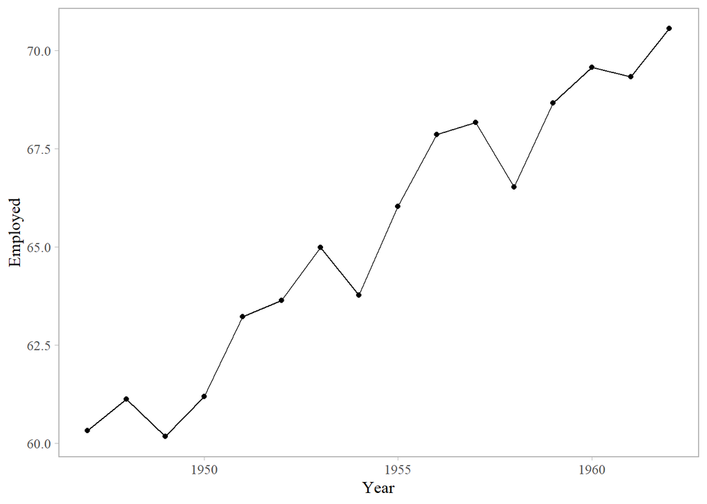

```r
data("longley")

q <- ggplot(longley, aes(x = Year, y = Employed)) +
  geom_point() +
  geom_line()

q
```

## Example with `tickr()`

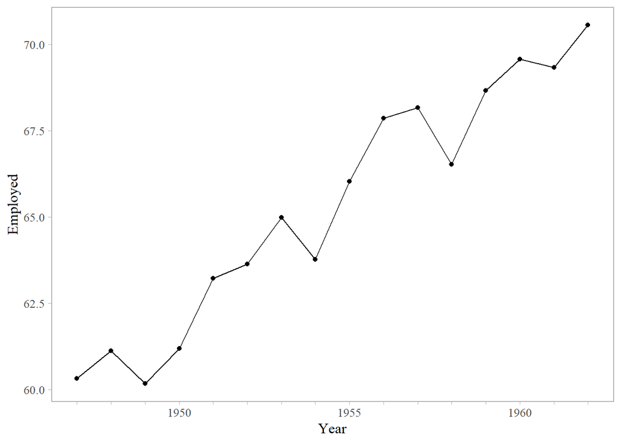

```r
axis <- tickr(longley, Year, 5)

q <- q + scale_x_continuous(breaks = axis$breaks, labels = axis$labels)

q
```

# ADF&G Plotting Library

Ben started an R package that houses `theme_sleek()` and `tickr()`.

You can access these and any future developments using the following code:

```r
# install.packages("devtools")
# devtools::install_github("ben-williams/FNGr")
# library("FNGr")
```

# Multipanelled plots

There’s been a long history of writing multipanelled plots in R. Remember `par(mfrow = c(2,2))`? For a long time I used the `grid.arrange()` function from the `gridExtra` package, but `cowplot`’s `plot_grid()` function makes this process so much easier and fine tuned.

You can check out `cowplot`’s vignettes on the topic for more advanced topics, but here I’ll show a couple simple examples https://cran.r-project.org/web/packages/cowplot/vignettes/plot_grid.html.

## Stacked figure

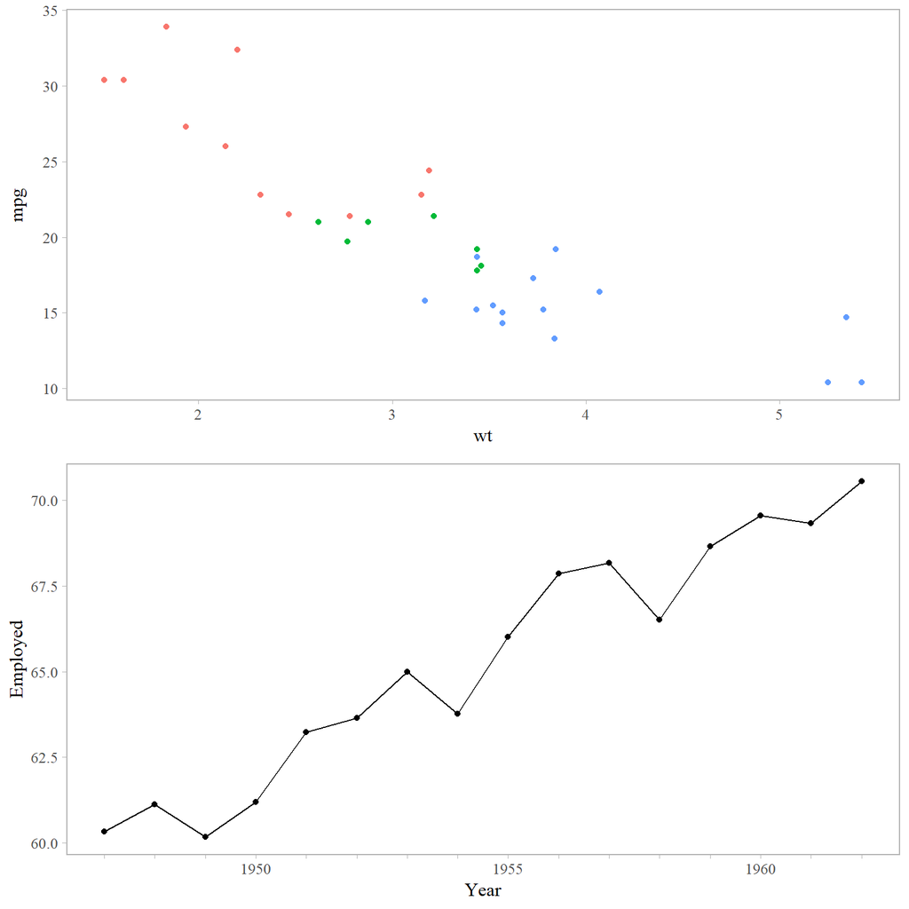

```r
p <- p + theme(legend.position = "none")

# stack figures (1 column) and align figs horizontally and vertically
pq <- cowplot::plot_grid(p, q, ncol = 1, align = "hv")

pq
```

## Multiple panels of different sizes

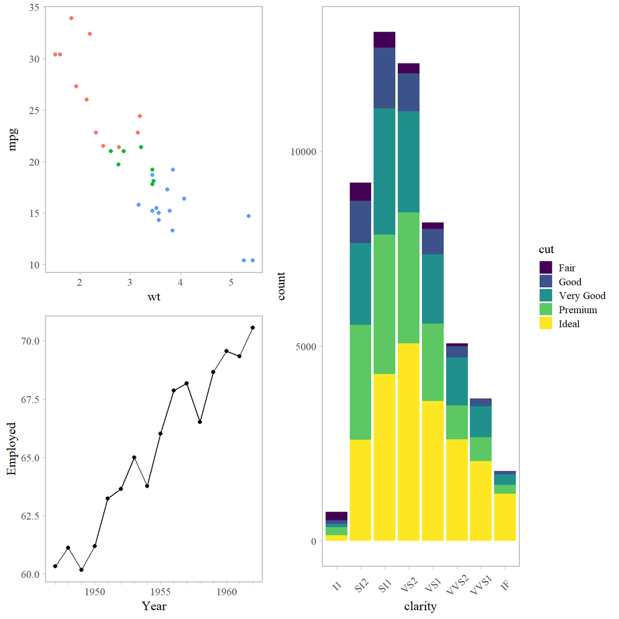

```r
r <- ggplot(diamonds, aes(clarity, fill = cut)) +
  geom_bar() +
  theme(axis.text.x = element_text(angle=45, vjust=0.5))

# Nest multipanelled plots and control the relative sizes of the associated figures
pqr <- cowplot::plot_grid(pq, r, ncol = 2, rel_widths = c(1, 1.3))

pqr
```

# Better labels with `ggrepel`

The `ggrepel` package makes labeling your data so much easier using its built-in algorithm for spacing labels. Use it the same way as `geom_text()`.

```r
if(!require("ggrepel"))   install.packages("ggrepel") # geom_text_repel()

# make the row names a separate column
mtcars$car <- row.names(mtcars)

head(mtcars)
```

```
##                    mpg cyl disp  hp drat    wt  qsec vs am gear carb
## Mazda RX4         21.0   6  160 110 3.90 2.620 16.46  0  1    4    4
## Mazda RX4 Wag     21.0   6  160 110 3.90 2.875 17.02  0  1    4    4
## Datsun 710        22.8   4  108  93 3.85 2.320 18.61  1  1    4    1
## Hornet 4 Drive    21.4   6  258 110 3.08 3.215 19.44  1  0    3    1
## Hornet Sportabout 18.7   8  360 175 3.15 3.440 17.02  0  0    3    2
## Valiant           18.1   6  225 105 2.76 3.460 20.22  1  0    3    1
##                                 car
## Mazda RX4                 Mazda RX4
## Mazda RX4 Wag         Mazda RX4 Wag
## Datsun 710               Datsun 710
## Hornet 4 Drive       Hornet 4 Drive
## Hornet Sportabout Hornet Sportabout
## Valiant                     Valiant
```

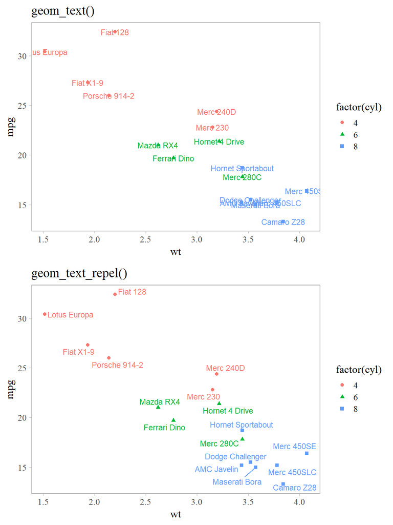

```r
mtcars %>%
  group_by(cyl) %>%
  # Subsample data
  sample_frac(0.5, replace = FALSE) -> mtcars2

p <- ggplot(mtcars2, aes(x = wt, y = mpg, colour = factor(cyl),
                         shape = factor(cyl), label = car)) +
  geom_point()

a <- p + geom_text(show.legend = FALSE, size = 3) +
  ggtitle("geom_text()")

b <- p + geom_text_repel(show.legend = FALSE, size = 3) +
  ggtitle("geom_text_repel()")

cowplot::plot_grid(a, b, ncol = 1)
```

# Resources for colour

IMHO if you don’t need colour, don’t use it! It’s distracting and if it doesn’t mean anything, what’s the point? Let `scale_colour_grey()` and `scale_fill_grey()` help.

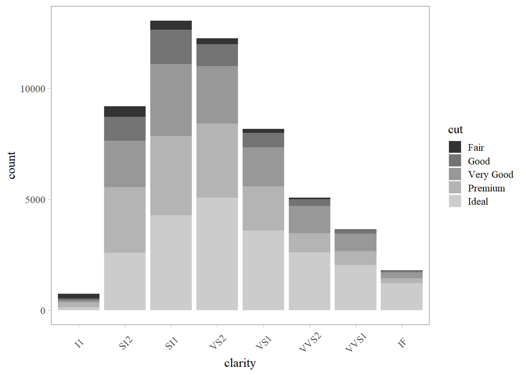

```r
r + scale_fill_grey()
```

But, if you must… here are my favorite colour libraries and resources:

The `RColorBrewer` library.

Colour blind, print friendly, photocopy safe colour schemes: http://colorbrewer2.org/#type=sequential&scheme=BuGn&n=3

Any colour you could ever want: http://www.color-hex.com

Beautiful colour schemes made by design students: https://www.canva.com/learn/100-color-combinations/

If you decide you want to use any of the Canva colour palettes, you’ll need to download the `ggthemes` library (and also the `RColorBrewer` library). The associated names of the palettes from the website above can be found at http://makeadifferencewithdata.com/wp-content/uploads/2016/12/color-palettes.txt.

Here’s an example of how to use a Canva colour palette:

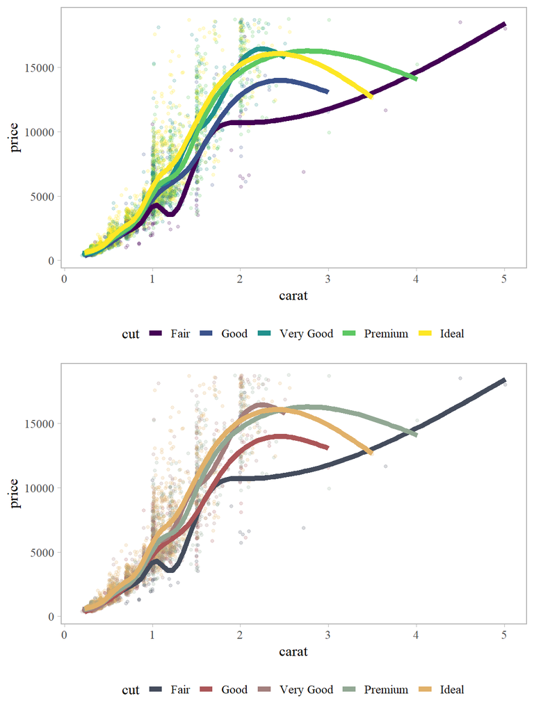

```r
if(!require("RColorBrewer"))   install.packages("RColorBrewer") # colorRampPalette() in this example but also has other uses with ggplot()
if(!require("ggthemes"))   install.packages("ggthemes") # canva_pal() but also has a ton of built-in themes to explore

# Some different options on canva.com
# pal <- ggthemes::canva_pal("Watery blue-greens")(4)
# pal <- ggthemes::canva_pal("Surf and turf")(4)
pal <- ggthemes::canva_pal("Warm and cool")(4)
# pal <- ggthemes::canva_pal("Pool party")(4)
# pal <- ggthemes::canva_pal("Trendy and metropolitan")(4)
# pal <- ggthemes::canva_pal("Fresh and bright")(4)

a <- ggplot(sample_frac(diamonds, 0.1, replace = FALSE),
            aes(x = carat, y = price, colour = cut)) +
  geom_point(alpha = 0.2, size = 1) +
  geom_smooth(se = FALSE, size = 2) +
  theme(legend.position = "bottom")

# ColorRampPalette increases the number of colour options within your pal
# options to the number of distinct levels of diamond's cut
b <- a + scale_colour_manual(values = colorRampPalette(pal)(n_distinct(diamonds$cut)))

cowplot::plot_grid(a, b, ncol = 1)
```

The `ggthemes` library also has a lot of built-in predefined themes. For a list of themes in the package check:

```r
ls("package:ggthemes")[grepl("theme_", ls("package:ggthemes"))]
```

```
##  [1] "theme_base"            "theme_calc"
##  [3] "theme_economist"       "theme_economist_white"
##  [5] "theme_excel"           "theme_excel_new"
##  [7] "theme_few"             "theme_fivethirtyeight"
##  [9] "theme_foundation"      "theme_gdocs"
## [11] "theme_hc"              "theme_igray"
## [13] "theme_map"             "theme_pander"
## [15] "theme_par"             "theme_solarized"
## [17] "theme_solarized_2"     "theme_solid"
## [19] "theme_stata"           "theme_tufte"
## [21] "theme_wsj"
```

# One last thing

This website is a fun place to learn more about how users have extended the base potential of `ggplot2`: https://www.ggplot2-exts.org.